# Assignment 3 Task 3: Text mining and analysis

Kirsten Hodgson

2/24/2021

```r
ps_tidy <- data.frame(philosophers_stone) %>%
  mutate(text_full = str_split(philosophers_stone, pattern = "\\n")) %>% #need two \ here to override operator
  unnest(text_full) %>%
  mutate(text_full = str_trim(text_full))

dh_tidy <- data.frame(deathly_hallows) %>%
  mutate(text_full = str_split(deathly_hallows, pattern = "\\n")) %>% #need two \ here to override operator
  unnest(text_full) %>%
  mutate(text_full = str_trim(text_full))

ps_df <- ps_tidy %>%
  mutate(chapter = 1:n())

dh_df <- dh_tidy %>%
  mutate(chapter = 1:n())

ps_tokens <- ps_df %>%
  unnest_tokens(word, text_full) %>%
  dplyr::select(-philosophers_stone)

#ps_count <- ps_tokens %>%
 # count(chapter, word)

dh_tokens <- dh_df %>%
  unnest_tokens(word, text_full) %>%
  dplyr::select(-deathly_hallows)

ps_nonstop_words <- ps_tokens %>%
  anti_join(stop_words)

ps_nonstop_counts <- ps_nonstop_words %>% count(word)

dh_nonstop_words <- dh_tokens %>%
  anti_join(stop_words)

dh_nonstop_counts <- dh_nonstop_words %>% count(word)
```

### Word Clouds

##### Exploring the most common words in *Harry Potter and the Philosopher’s Stone* and *Harry Potter and the Deathly Hallows*

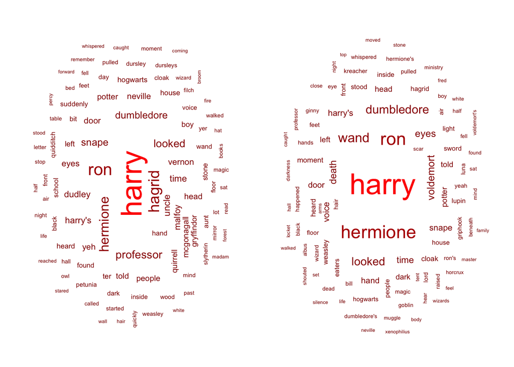

```r
dh_top_100 <-
  dh_nonstop_counts %>%
  arrange(-n) %>%
  slice(1:100) %>%
  mutate(angle = 90 * sample(c(0,1), n(), replace = TRUE, prob = c(70,30)))

dh_cloud <- ggplot(dh_top_100, aes(label = word, angle = angle)) +
  geom_text_wordcloud(aes(color = n, size = n), shape = "circle", eccentricity = 1) +
  scale_size_area(max_size = 10) +
  theme_void() +
  scale_color_gradient(low = "darkred", high = "red")

ps_top_100 <-
  ps_nonstop_counts %>%
  arrange(-n) %>%
  slice(1:100) %>%
  mutate(angle = 90 * sample(c(0,1), n(), replace = TRUE, prob = c(70,30)))

ps_cloud <- ggplot(ps_top_100, aes(label = word, angle = angle)) +
  geom_text_wordcloud(aes(color = n, size = n), shape = "circle", eccentricity = 1) +
  scale_size_area(max_size = 10) +
  theme_void() +
  scale_color_gradient(low = "darkred", high = "red")

ps_dh_cloud <- (ps_cloud | dh_cloud)

ps_dh_cloud
```

**Figure 1.** Word cloud exploration of the most common words in *Harry Potter and the Philosopher’s Stone* (left) and *Harry Potter and the Deathly Hallows* (right). The most common word in both novels is “Harry”. Also common are the names of other main characters such as Hermione, Ron, and Dumbledore.

### Sentiment Analysis

```r
afinn <- get_sentiments("afinn")

ps_afinn <- ps_nonstop_words %>%
  inner_join(get_sentiments("afinn"))

ps_afinn_counts <- ps_afinn %>%
  count(chapter, value)

ps_afinn_means <- ps_afinn %>%
  group_by(chapter) %>%
  summarize(mean_afinn = mean(value)) %>%
  mutate(sign = case_when(mean_afinn >= 0 ~ "positive",
                          mean_afinn < 0 ~ "negative"))

dh_afinn <- dh_nonstop_words %>%
  inner_join(get_sentiments("afinn"))

dh_afinn_counts <- dh_afinn %>%
  count(chapter, value)

dh_afinn_means <- dh_afinn %>%
  group_by(chapter) %>%
  summarize(mean_afinn = mean(value)) %>%
  mutate(sign = case_when(mean_afinn >= 0 ~ "positive",
                          mean_afinn < 0 ~ "negative"))
```

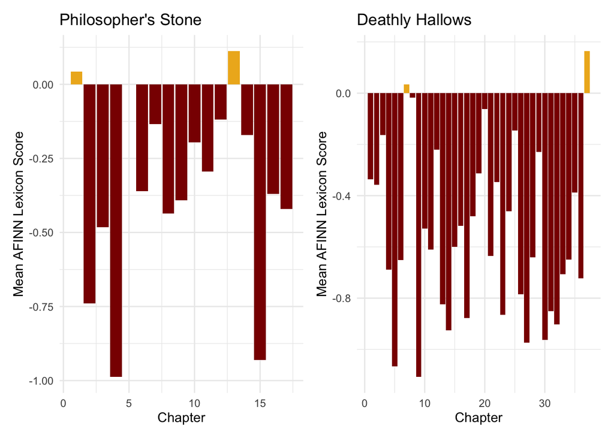

```r
ps_afinn_plot <- ggplot(data = ps_afinn_means,
                        aes(x = chapter,
                            y = mean_afinn)) +
  geom_col(aes(fill = sign)) +
  theme_minimal() +
  scale_fill_manual(values = c("darkred", "goldenrod2")) +
  labs(x = "Chapter",
       y = "Mean AFINN Lexicon Score",
       title = "Philosopher's Stone") +
  theme(legend.position = "none")

dh_afinn_plot <- ggplot(data = dh_afinn_means,
                        aes(x = chapter,
                            y = mean_afinn)) +
  geom_col(aes(fill = sign))  +
  theme_minimal() +
  scale_fill_manual(values = c("darkred", "goldenrod2")) +
  labs(x = "Chapter",
       y = "Mean AFINN Lexicon Score",
       title = "Deathly Hallows") +
  theme(legend.position = "none")

ps_dh_afinn_plot <- (ps_afinn_plot | dh_afinn_plot)

ps_dh_afinn_plot
```

**Figure 2.** Sentiment analysis by chapter of *Harry Potter and the Philosopher’s Stone* (left) and *Harry Potter and the Deathly Hallows* (right) using the AFINN Sentiment Lexicon to calculate mean chapter sentiment on a scale of positivity/negativity. Both books are overwhelmingly negative, though *Harry Potter and the Deathly Hallows* is more so, with a larger number of chapters having more negative mean scores. In both books, only two chapter have positive mean scores. Notably, the last chapter of *Harry Potter and the Deathly Hallows* is mean positive. This aligns with the text as this chapter is the epilogue, which ends the entire series with the line “All was well”.